# 보고서_박상우

민형규, 박상우, 정민지, 최호경

2019-12-13

# 서울시 축제 대백과

# 1. 프로젝트 개요

## 1-1 배경

-기존의 축제 추천 앱 및 사이트의 한계점

1. 전국의 주요 축제만을 소개
2. 단순 정보 전달에 한정, 분석 정보 전달에 미흡

## 1-2 목적

-기존의 서비스의 장점 계승 및 단점 보완을 통한 개선된 서비스 제공

*장점 계승

1. 지역 기반 주변 정보 전달 벤치마킹
2. 사용자 정보 기반 맞춤형 서비스 제공 벤치마킹

*단점 보완

3. 전국이 주요 축제가 아닌 서울의 모든 축제 정보 전달
4. 피상적인 정보 전달이 아닌 데이터 분석 기반 직관적 정보의 제공을 통한 보완

## 1-3 서비스 소개

1. 키워드 정보 제공
2. 연령별 이용자 비율 제공

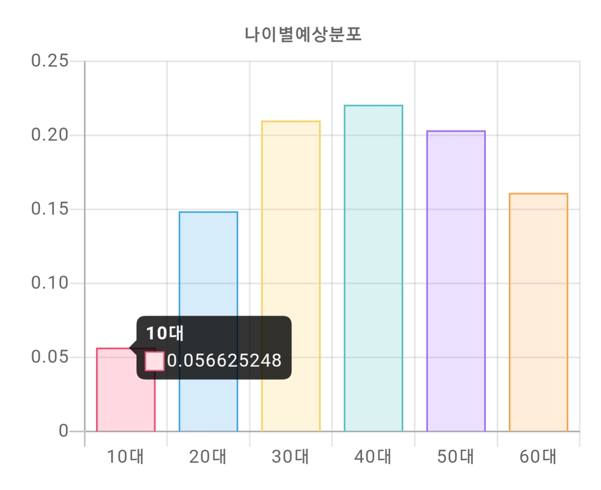

3. 성별 이용자 비율 제공

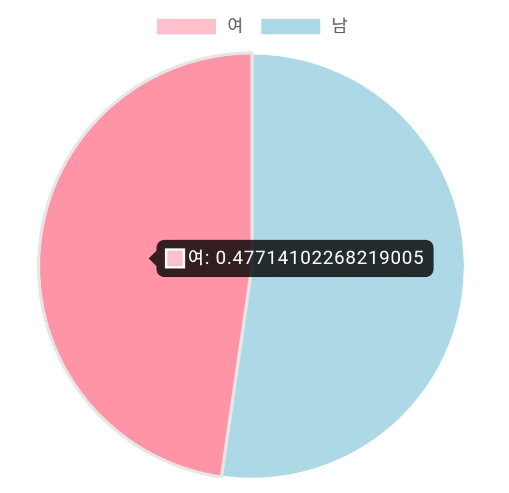

4. 주변 지역 정보 제공

[figure not shown]

## 3-4 성별 이용자 비율 예측 모델

### 개요

이번에는 Y의 6개의 연령별 비율을 성별을 기준으로 합해주었다.

여성 이용자 비율은 1-남성 비율로 도출해 낼 수 있기에 남성 이용자 비율을 예측하는 모델링을 짜보았다.

### 모델링

[남성 이용자 비율 예측 파일]

-modeling/Man proportion prediction/데이터 전처리.jpynb

-modeling/Man proportion prediction/남성비율예측+변수중요도.html